# Prosper Loan Data Exploration

## by Lana Palmer

## Investigation Overview

> In this project I will explore a data set provided by Prosper Marketplace.

## Dataset Overview

> Prosper Marketplace, Inc. is a privately-held, San Francisco-based company in the peer-to-peer lending industry. This dataset includes information on loans funded through the marketplace.

## The ProsperScore: Average Score

The ProsperScore is a custom risk score built using historical Prosper data. Each borrower is assigned a score ranging from 1.0 (highest risk) to 10.0 (lowest risk). Lenders may use this score when choosing loans to fund. The next slide shows the range of ProsperScores, with an average of 5.86.

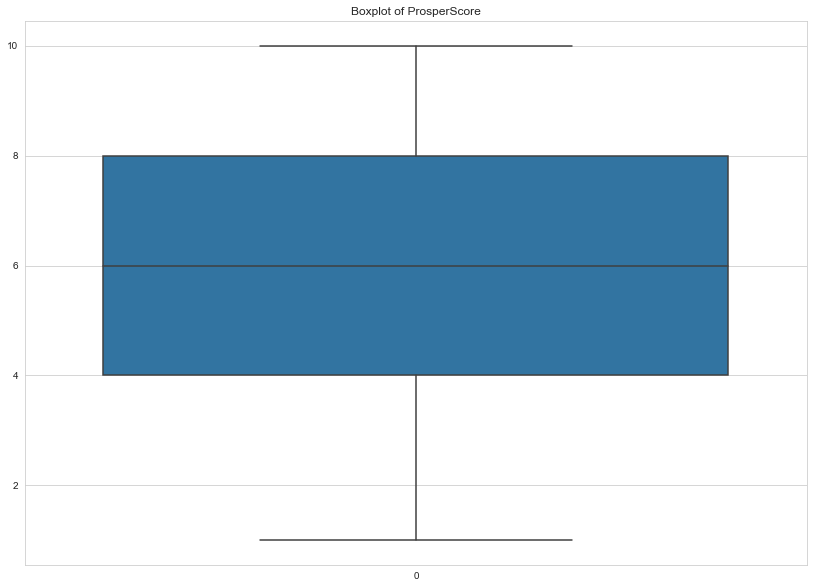

```python
#Plot Boxplot
plt.figure(figsize=(14, 10))
sns.set_style('whitegrid')
ax = sns.boxplot(data=[prosper_c['ProsperScore']])
ax.set_title('Boxplot of ProsperScore');
```

## The ProsperScore: Score Range

> As the next slide illustrates, most borrowers have scores between 4 and 8, and very few have scores below 2.

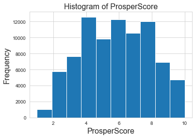

```python
#Plot Histogram
plt.figure(figsize=(60, 60))
prosper_c.hist(column='ProsperScore')
plt.ylabel('Frequency', fontsize=16)
plt.xlabel('ProsperScore', fontsize=16)
plt.title('Histogram of ProsperScore', fontsize=16);
```

## ProsperScore vs Lender Yield

The Lender Yield is equal to the interest rate on the loan less the Prosper servicing fee. As we see in the following slide, the lowest ranked borrowers, with a ProsperScore of 1.0, have a mean Lender Yield which is dramatically higher than the highest-ranked borrowers.

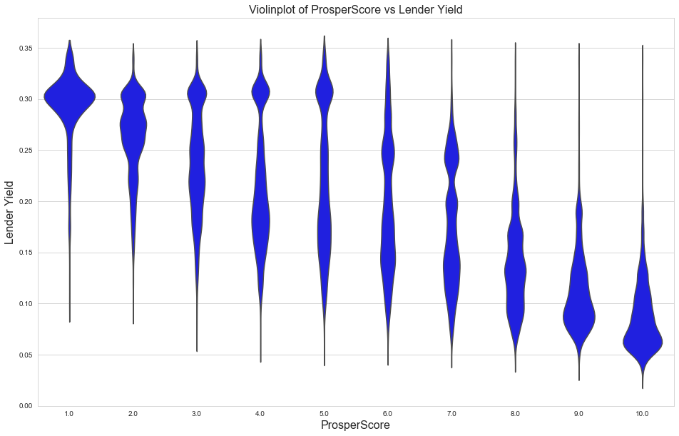

```python
#Plot Violinplot
plt.figure(figsize=(16, 10))

sns.violinplot(data = prosper_c, x = 'ProsperScore', y = 'LenderYield', color = 'blue',
              inner = None)
plt.title('Violinplot of ProsperScore vs Lender Yield', fontsize=16)

plt.ylabel('Lender Yield', fontsize=16)
plt.xlabel('ProsperScore', fontsize=16);
```

## ProsperScore, Lender Yields and Investors

The number of investors for each loan in the dataset ranged from 1 to 1200, with an average of 80 investors per loan. The next slide shows the correlation between the number of investors, prosper score, and lender yield. We see that:

- LenderYield and ProsperScore have a strong negative correlation (-0.64)
- LenderYield and the number of Investors have a negative correction (-0.24)
- The ProsperScore and the number of investors have a positive correlation (0.33)

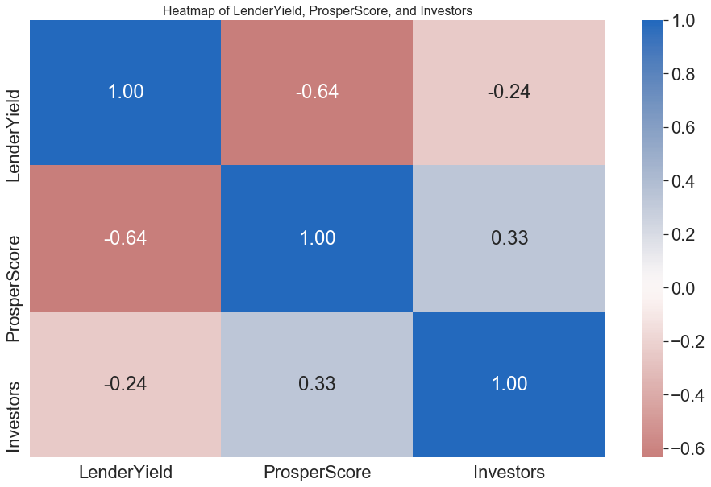

```python
#Plotting Heatmap of LenderYield, ProsperScore, and Investors
plt.figure(figsize=(16, 10))
sns.set(font_scale=2)
plt.title('Heatmap of LenderYield, ProsperScore, and Investors', fontsize=16)
sns.heatmap(prosper_s.corr(), annot = True, fmt = '.2f', cmap = 'vlag_r', center = 0);
```